# ЕГЭ 2017 Вариант 10 EGE 2017 Variant 10

### The variant from the book was used: [ЕГЭ-2017. Информатика.10 тренировочных вариантов. Ушаков Д.М.](https://drive.google.com/file/d/0B6696ckkWj_zS2ptblAxNERHZzQ/view)

## Часть 1 Part 1

```python
%%html
<style>
@import url('https://fonts.googleapis.com/css?family=Roboto&effect=3d|scuffed-steel|static|brick-sign|canvas-print|');
body {background-color: aliceblue;}
a {color: #4876ff; font-family: 'Roboto';}
h1 {color: #348ABD; font-family: 'Roboto'; text-shadow: 4px 4px 4px #aaa;}
h2, h3 {color: gray; font-family: 'Roboto'; text-shadow: 4px 4px 4px #aaa;}
h4 {color: #348ABD; font-family: 'Roboto';}
span {text-shadow: 4px 4px 4px #aaa;}
div.output_prompt, div.output_area pre, div.output_subarea {color: gray;}
div.input_prompt {color: #4876ff;}
div.output_stderr pre {background-color: aliceblue;}
div.output_stderr {background-color: gray;}
</style>
```

```python
answer_dictionary = dict()
```

[figure not shown]

Сколько единиц в двоичной записи числа 197?

How many units are in the binary record of the number 197?

```python
2 ** 7 + 2 ** 6 + 2 ** 2 + 2 ** 0
```

```
197
```

Всего 4 ненулевых коэффициента степеней числа 2 в бинарной форме числа 197.

There are 4 nonzero coefficients of powers of 2 in the binary form of the number 197.

```python
bin(197)[2:]
```

```
'11000101'
```

```python
answer_dictionary[1] = str(bin(197)[2:].count('1'))
print ("\n","Answer:",answer_dictionary[1])
```

```
 Answer: 4
```

[figure not shown]

Дан фрагмент таблицы истинности выражения F, зависящего от трёх аргументов X, Y, Z:

A fragment of the truth table for the expression F, depending on the three arguments X, Y, Z, is given:

| $X$ | $Y$ | $Z$ | $F$ |
| --- | --- | --- | --- |
| 0 | 0 | 1 | 0 |
| 1 | 1 | 0 | 1 |
| 0 | 1 | 1 | 0 |

Перечислите в порядке возрастания без запятых и пробелов номера логических выражений, которые соответствуют F:

List in ascending order without commas and spaces the numbers of logical expressions that correspond to F:

$ 1) \ X \land Y \lor \neg Z$

$ 2) \ \neg X \land \neg Y \land \neg Z$

$ 3) \ X \land Y \land \neg Z$

$ 4) \ X \lor Y \lor \neg Z$

$ 5) \ X \lor Y \land \neg Z$

```python
binary_combinations = [[0,0,1,0],[1,1,0,1],[0,1,1,0]]

def f(x,y,z,i):
    if i == 1:
        return (x and y or not z)
    if i == 2:
        return (not x and not y and not z)
    if i == 3:
        return (x and y and not z)
    if i == 4:
        return (x or y or not z)
    if i == 5:
        return (x or y and not z)

answer = ''

for i in range(5):
    result = []

    for (x,y,z,F) in binary_combinations:
        result.append(f(x,y,z,i+1) == F)
    print('\n', str(i+1)+')', result)

    if result == 3*[True]:
        answer = answer + str(i+1)

answer_dictionary[2] = answer
print ("\nAnswer:",answer_dictionary[2])
```

```
 1) [True, True, True]

 2) [True, False, True]

 3) [True, True, True]

 4) [True, True, False]

 5) [True, True, True]

Answer: 135
```

[figure not shown]

В таблице приведена стоимость перевозок между соседними железнодорожными станциями.

Перечислите в порядке возрастания, без пробелов и запятых, номера схем, соответствующих таблице.

The table shows the cost of transportation between neighboring railway stations.

In the ascending order, without spaces or commas, list the schema numbers corresponding to the table.

| 𒏏 | A | B | C | D | E |
| --- | --- | --- | --- | --- | --- |
| **A** | 𒏏 | 2 |  |  |  |
| **B** | 2 | 𒏏 | 5 | 4 |  |
| **C** |  | 5 | 𒏏 | 7 | 3 |
| **D** |  | 4 | 7 | 𒏏 |  |
| **E** |  |  | 3 |  | 𒏏 |

```python
import networkx as nx
import pandas
import matplotlib.pyplot as plt
%matplotlib inline

df = pandas.DataFrame(index=['A', 'B', 'C', 'D', 'E'],
                      columns=['A', 'B', 'C', 'D', 'E'])
df = df.fillna(0)
df['A']['B'] = 2
df['B']['A'], df['B']['C'], df['B']['D'] = 2, 5, 4
df['C']['B'], df['C']['D'], df['C']['E'] = 5, 7, 3
df['D']['B'], df['D']['C'] = 4, 7
df['E']['C'] = 3

df
```

|  | A | B | C | D | E |
| --- | --- | --- | --- | --- | --- |
| A | 0 | 2 | 0 | 0 | 0 |
| B | 2 | 0 | 5 | 4 | 0 |
| C | 0 | 5 | 0 | 7 | 3 |
| D | 0 | 4 | 7 | 0 | 0 |
| E | 0 | 0 | 3 | 0 | 0 |

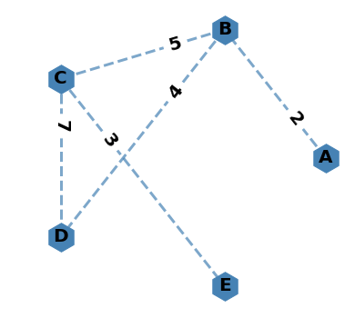

```python
plt.figure(figsize=(6,6))
G = nx.from_pandas_adjacency(df)
pos = nx.shell_layout(G)

nx.draw_networkx_nodes(G,pos,node_size=1000,node_shape="h",
                       node_color='steelblue')
nx.draw_networkx_labels(G,pos,font_size=20,font_weight='bold')
nx.draw_networkx_edges(G,pos,width=3,alpha=0.7,
                       edge_color='steelblue',style='dashed')
edge_labels = \
dict([((u,v,),d['weight']) for u,v,d in G.edges(data=True)])
nx.draw_networkx_edge_labels(G,pos,font_size=20,font_weight='bold',
                             label_pos=0.7, edge_labels=edge_labels)

plt.axis('off');
```

```python
answer_dictionary[3] = '4'
print ("\nAnswer:",answer_dictionary[3])
```

```
Answer: 4
```

[figure not shown]

Для групповых операций с файлами используются маски имён файлов.

Маска представляет собой последовательность букв, цифр и прочих допустимых в именах файлов символов,

в которой также могут встречаться следующие символы.

Символ `«?»` (вопросительный знак) означает ровно один произвольный символ.

Символ `«*»` (звёздочка) означает любую последовательность символов произвольной длины, в том числе `«*»` может задавать и пустую последовательность.

В каталоге находятся шесть файлов:

`boom.pas`, `bloom.ppt`, `loom.pas`, `bottom.pdf`, `bom.pps`, `boom.ppt`.

Ниже представлено восемь масок. Сколько из них таких, которым соответствует ровно четыре файла из данного каталога?

`?oo*m.p*`, `b*o*om.p??`, `*o*om.p*?`, `b*om.p?*`, `*.*p*`, `bo*m.???`, `*om.*p*`, `*o*o*.p*?`.

For group operations with files, masks of file names are used.

A mask is a sequence of letters, numbers and other permissible characters in file names,

in which the following characters can also occur.

The symbol `«?»` (question mark) means exactly one arbitrary character.

The symbol `«*»` (asterisk) stands for any sequence of characters of arbitrary length, including `«*»`, which can also specify an empty sequence.

There are six files in the directory:

`boom.pas`, `bloom.ppt`, `loom.pas`, `bottom.pdf`, `bom.pps`, `boom.ppt`.

Here are eight masks. How many of them are those to which exactly four files from this catalog correspond?

`?oo*m.p*`, `b*o*om.p??`, `*o*om.p*?`, `b*om.p?*`, `*.*p*`, `bo*m.???`, `*om.*p*`, `*o*o*.p*?`.

```python
import fnmatch
import os
mask_list = ['?oo*m.p*','b*o*om.p??','*o*om.p*?', 'b*om.p?*',
             '*.*p*','bo*m.???','*om.*p*', '*o*o*.p*?']
file_list = ['boom.pas', 'bloom.ppt', 'loom.pas',
             'bottom.pdf', 'bom.pps', 'boom.ppt']
answer_list = [[],[],[],[],[],[],[],[]]
c = 0

for i,mask in enumerate(mask_list):
    for j,file in enumerate(file_list):
        if fnmatch.fnmatch(file, mask):
            print (i+1,mask,j+1,file)
            answer_list[i].append(str(j+1))
    if len(answer_list[i]) == 4:
        c += 1

print(answer_list)
answer_dictionary[4] = str(c)
print("\n","Answer:",answer_dictionary[4])
```

```
1 ?oo*m.p* 1 boom.pas
1 ?oo*m.p* 3 loom.pas
1 ?oo*m.p* 6 boom.ppt
2 b*o*om.p?? 1 boom.pas
2 b*o*om.p?? 2 bloom.ppt
2 b*o*om.p?? 4 bottom.pdf
2 b*o*om.p?? 6 boom.ppt
3 *o*om.p*? 1 boom.pas
3 *o*om.p*? 2 bloom.ppt
3 *o*om.p*? 3 loom.pas
3 *o*om.p*? 4 bottom.pdf
3 *o*om.p*? 6 boom.ppt
4 b*om.p?* 1 boom.pas
4 b*om.p?* 2 bloom.ppt
4 b*om.p?* 4 bottom.pdf
```

[output cut: 26 more lines]

```python
for mask in mask_list:
    print(fnmatch.translate(mask))
```

```
(?s:.oo.*m\.p.*)\Z
(?s:b.*o.*om\.p..)\Z
(?s:.*o.*om\.p.*.)\Z
(?s:b.*om\.p..*)\Z
(?s:.*\..*p.*)\Z
(?s:bo.*m\....)\Z
(?s:.*om\..*p.*)\Z
(?s:.*o.*o.*\.p.*.)\Z
```

[figure not shown]

Через канал связи передаётся сообщение, состоящее только из символов А, Б, В и Г.

Эти символы кодируются неравномерным (по длине) кодом: *A-0, Б-10, В-110, Г-111*.

Исходное сообщение: *ВГВБАВА*.

Закодируйте сообщение приведенным кодом.

Полученную последовательность переведите в шестнадцатеричный вид.

В ответе запишите последовательность шестнадцатеричных цифр без запятых.

A message is sent through the communication channel, it consists only of symbols А, Б, В and Г.

These symbols are encoded unequally (along with the length) by code: *A-0, Б-10, В-110, Г-111*.

The initial message: *ВГВБАВА*.

Encode the message with this code.

Obtain the resulting sequence in a hexadecimal form.

In the answer, write down the sequence of hexadecimal digits without commas.

```python
string = 'ВГВБАВА'.replace('А','0').replace('Б','10').replace('В','110').replace('Г','111')
string
```

```
'1101111101001100'
```

Четыре цифры в бинарной системе соответствуют одной цифре в шестнадцатеричной системе.

The four digits in the binary system correspond to one digit in the hexadecimal system.

$1101_2 = 2^3 + 2^2 + 2^0 = 13_{10} = D_{16}$

$1111_2 = 2^3 + 2^2 + 2^1 + 2^0 = 15_{10} = F_{16}$

$0100_2 = 2^2 = 4_{10} = 4_{16}$

$1100_2 = 2^3 + 2^2 = 12_{10} = C_{16}$

$1101111101001100_2 = DF4C_{16}$

```python
number = hex(int(string,2))[2:].upper()
number
```

```
'DF4C'
```

```python
answer_dictionary[5] = number
print("\n","Answer:",answer_dictionary[5])
```

```
 Answer: DF4C
```

[figure not shown]

Предлагается некоторая операция над двумя произвольными трёхзначными десятичными числами:

$1.$ Записывается результат сложения значений старших разрядов заданных чисел.

$2.$ К нему дописывается результат сложения значений средних разрядов этих чисел по такому правилу: если он меньше первой суммы, то второе полученное число приписывается к первому слева, иначе — справа.

$3.$ Итоговое число получают приписыванием справа к полученному после второго шага числу суммы значений младших разрядов исходных чисел.

Какие из предложенных чисел могут быть результатом такой операции?

Перечислите в алфавитном порядке буквы, соответствующие этим числам, без пробелов и знаков препинания.

The operation on two arbitrary three-digit decimal numbers is sopposed by this way:

$1.$ The result of the addition of the highest digits in the given numbers is written down.

$2.$ The result of the addition of the mean digits is written near to it by this rule: if it is less than the first sum, then the second obtained number is joined to the first from the left, otherwise - from the right.

$3.$ The final number is obtained by joining from the right the sum of the lowest digits of the original numbers to the number written after the second step.

Which of the suggested numbers can be the result of this operation?

List in alphabetical order the letters corresponding to these numbers, without spaces and punctuation marks.

$A) \ 171412$

$B) \ 121419$

$C) \ 81714$

$D) \ 15117$

$E) \ 4809$

$A) \ 171412$

Содержит 6 символов, значит результатом сложения каждой пары цифр было двузначное число (17, 14, 12). Но 17 больше 14, а первые две суммы должны быть в возрастающем порядке.

Contains 6 symbols, therefore the result of addition of each pair of digits was a two-digit number (17, 14, 12). But 17 is more than 14, and the first two sums should be in ascending order.

$B) \ 121419$

Содержит 6 символов, значит результатом сложения каждой пары цифр было двузначное число (12, 14, 19). Но 19 не может быть получено путем сложения двух цифр.

Contains 6 symbols, therefore the result of addition of each pair of digits was a two-digit number (12, 14, 19). But 19 can not be obtained by adding two digits.

$C) \ 81714 \to 8, 17, 14 \to 497, 487$

$D) \ 15117$

Содержит 5 символов, значит результатом сложения одной пары цифр было однозначное число 7 или 1 в середине. Но 15 больше 11 или 1, а первые две суммы должны быть в возрастающем порядке.

Contains 5 characters, so the result of adding one pair of digits was a single digit: 7 or 1 in the middle. But 15 is more than 11 or 1, and the first two sums should be in ascending order.

$E) \ 4809$

Невозможно разбить на три суммы пар цифр: 4,8,09; 48,0,9; 4,80,9.

It is impossible to break down into sums of digit pairs: 4,8,09; 48,0,9; 4,80,9.

```python
answer_dictionary[6] = 'C'
print("\n","Answer:",answer_dictionary[6])
```

```
 Answer: C
```

[figure not shown]

В электронной таблице значение формулы `=СРЗНАЧ(А3:D4)` равно 5.

Чему равно значение формулы `=СРЗНАЧ(А3:С4)`, если значение формулы `=СУММ(D3:D4)` равно 4?

In the spreadsheet, the value of the formula `=AVERAGE(A3:D4)` is 5.

What is the value of the formula `=AVERAGE(A3:C4)` if the value of the formula `=SUM(D3:D4)` is 4?

[Google Sheet](https://drive.google.com/open?id=178gvK3PdsrJH7TTnXQKJrJxwXiG69NWkl0FSCU7NZSs)

[figure not shown]

```python
AVERAGE_A3_D4, SUM_D3_D4 = 5, 4
AVERAGE_A3_C4 = int((8 * AVERAGE_A3_D4 - SUM_D3_D4) / 6)

answer_dictionary[7] = AVERAGE_A3_C4
print("\n","Answer:",answer_dictionary[7])
```

```
 Answer: 6
```

[figure not shown]

Определите, что будет напечатано в результате выполнения следующего фрагмента программы:

Determine what will be printed as a result of execution of the following program fragment:

Python

R

```python
k,s = 0,5
while s < 205:
    s += 10
    k += 1

print (k)
```

```r
k <- 0; s <- 5

while (s < 205) {
    s <- s + 10
    k <- k + 1
}

print(k)
```

BASIC

Pascal

```
DIM k, s AS INTEGER
k = 0
s = 5
WHILE s < 205
    s = s + 10
    k = k + 1
WEND
PRINT k
```

```
var k, s : integer;
begin
    k := 0;
    s := 5;
    while s < 205 do
        s := s + 10;
        k := k + 1;
    end;
    write(k);
end.
```

C

Natural Language Programming

```c
{
    int k, s;
    k = 0;
    s = 5;
    while (s < 205)
    {
        s = s + 10;
        k = k + 1;
    }
    printf("%d", k);
}
```

```
нач
    цел k, s
    k := 0
    s := 5
    нц пока s < 205
        s := s + 10
        k := k + 1
    кц
    вывод k
кон
```

```python
k,s = 0,5
while s < 205:
    s += 10
    k += 1

print (k)
```

```
20
```

```python
answer_dictionary[8] = str(k)
print("\n","Answer:", answer_dictionary[8])
```

```
 Answer: 20
```

[figure not shown]

Скольких различных цветов (наибольшее количество) могут быть пиксели неупакованного растрового изображения,

имеющего размер 1024X256 пикселей и занимающего на диске 160 килобайт?

How many different colors (the largest number) can be the pixels of the unpacked raster image,

which has a size of 1024X256 pixels and occupies 160 KB on the disk?

| Размер изображения в битах / Image Size in Bits | $160 * 2^3 * 2^{10}$ |
| --- | --- |
| Бит на один пиксель / Bits per Pixel | $160 * 2^3 * 2^{10} / (1024 * 256)$ |
| Количество цветов / Number of Colors | $\large{2^{(160 * 2^3 * 2^{10} / (1024 * 256))}}$ |

```python
image_size_in_bits = 160 * 2 ** 3 * 2 ** 10
bits_per_pixel = int(image_size_in_bits / (1024 * 256))
number_of_colors = 2 ** (bits_per_pixel)
```

```python
answer_dictionary[9] = str(number_of_colors)
print("\n","Answer:", answer_dictionary[9])
```

```
 Answer: 32
```

[figure not shown]

Азбука Морзе позволяет кодировать символы для сообщений по радиосвязи, задавая комбинацию точек и тире.

Сколько различных символов (цифр, букв, знаков пунктуации и т. д.) можно закодировать,

используя код Морзе длиной не менее трёх и не более четырёх сигналов (точек и тире)?

The Morse code allows you to encode characters for messages on the radio by specifying a combination of dots and dashes.

How many different characters (numbers, letters, punctuation marks, etc.) can be encoded

using Morse code of at least three and not more than four signals (dots and dashes)?

Сигнальная система Морзе - бинарная, состоит из двух символов: точка и тире.

Сообщений длиной 3 символа будет $2^3$, а длиной 4 символа - $2^4$.

The Morse signal system is binary, consists of two symbols: a dot and a dash. Messages of 3 characters in length will be $2^3$, and 4 characters in length - $2^4$.

```python
answer_dictionary[10] = str(2 ** 3 + 2 ** 4)
print("\n","Answer:", answer_dictionary[10])
```

```
 Answer: 24
```

[figure not shown]

Алгоритм вычисления значения функции $F(n)$, где $n$ — натуральное число, задан следующими соотношениями:

$F(n) = F(n - 1) * n$, при $n > 1$

$F(1) = 1$

Чему равно значение функции $F(6)$?

The algorithm for calculating the value of the function $F(n)$, where $n$ is a natural number, is given by the following relations:

$F(n) = F(n - 1) * n$, при $n > 1$

$F(1) = 1$

What is the value of the function $F(6)$?

```python
def F(n):
    if n == 1:
        return 1
    else:
        return F(n - 1) * n

answer_dictionary[11] = str(F(6))
print("\n","Answer:",answer_dictionary[11])
```

```
 Answer: 720
```

[figure not shown]

На месте преступления были обнаружены четыре обрывка бумаги.

Следствие установило, что на них записаны фрагменты одного IP-адреса.

Криминалисты обозначили эти фрагменты буквами A, B, C и D.

Восстановите IP-адрес.

В ответе укажите последовательность букв, обозначающих фрагменты, в порядке, соответствующем IP-адресу.

At the crime scene, four pieces of paper were found.

The investigation found they were recorded fragments of one IP-address.

The forensic scientists designated these fragments by the letters A, B, C, and D.

Restore the IP address.

In the answer, specify the sequence of letters indicating the fragments, in the order corresponding to the IP address.

| *.75* | *5.106* | *21* | *1.24* |
| --- | --- | --- | --- |
| $\large{A}$ | $\large{B}$ | $\large{C}$ | $\large{D}$ |

IP-адрес (IPv4) является 32-битовым (4-байтовым) числом, запись которого состоит из последовательности 4 десятичных чисел с максимальным значением 255. Например: *192.168.0.3*.

Адрес в задаче содержит 14 символов: 11 цифр и три точки.

Фрагмент $C$ - *21* начинается с двух цифр, но нет фрагментов, заканчивающихся точкой, которых можно было бы присоединить слева. Значит, $C$ и есть первая часть адреса.

Фрагмент $A$ - *.75* может быть только последним по той же причине. Кроме того, этот байт содержит две цифры, иначе он превысит значение 255.

Цифр всего 11, поэтому остальные байты должны быть трехзначными числами. Значит, перед $A$ может быть только $B$.

Для $D$ остается только второе место в последовательности букв: $CDBA$.

The IP address (IPv4) is a 32-bit (4-byte) number whose record consists of a sequence of 4 decimal numbers with a maximum value of 255. For example: *192.168.0.3*.

The address in the task contains 14 characters: 11 digits and 3 dots.

Fragment $C$ - *21* starts with two digits, but there are no fragments ending with a dot that could be attached to the left. Hence, $ C $ is the first part of the address.

Fragment $A$ - *.75* can only be the last one for the same reason. In addition, this byte contains two digits, otherwise it will exceed 255.

The number of digits is 11, so the remaining bytes must be three-digit numbers. Hence, there can be only $B$ before $A$.

For $D$, only the second place in the sequence of letters remains: $CDBA$.

```python
answer_dictionary[12] = 'CDBA'
print("\n","Answer:",answer_dictionary[12])
```

```
 Answer: CDBA
```

[figure not shown]

Репетиционный экзамен в школе сдают 105 человек.

Каждому из них выделяют специальный номер, идентифицирующий его в автоматической системе проверки ответов.

При регистрации участника для записи его номера система использует минимально возможное количество бит, одинаковое для каждого участника.

Каков объём информации в битах, записанный устройством после регистрации 60 участников?

A rehearsal school exam is passed by 105 people.

Each of them is allocated a special number that identifies it in an automatic system for verifying answers.

For registering a participant to record its number, the system uses the minimum possible number of bits, the same for each participant.

What is the amount of information in bits recorded by the device after registering 60 participants?

```python
import math
bits_for_one_of_105_participants = math.ceil(math.log(105,2))

answer_dictionary[13] = str(60 * bits_for_one_of_105_participants)
print("\n","Answer:",answer_dictionary[13])
```

```
 Answer: 420
```

[figure not shown]

Система команд исполнителя РОБОТ, «живущего» в прямоугольном лабиринте на клетчатой плоскости включает

4 команды-приказа и 4 команды проверки условия. Команды-приказы:

The command system of the ROBOT, "living" in a rectangular labyrinth on the grid plane, includes

4 moving commands and 4 condition-checking ones. Moving commands:

| вверх | вниз | влево | вправо |
| --- | --- | --- | --- |
| up | down | left | right |

При выполнении этих команд РОБОТ перемещается на одну клетку соответственно: вверх ↑, вниз ↓, влево ←, вправо →.

Если РОБОТ начнет движение в сторону находящейся рядом с ним стены, то он разрушится и программа прервётся.

Другие четыре команды проверяют истинность условия отсутствия стены у каждой стороны той клетки, где находится РОБОТ:

When these commands are executed, ROBOT moves one cell accordingly: up ↑, down ↓, left ←, right →.

If ROBOT starts moving towards the wall next to it, it will be destroyed and the program will be stopped.

The other four commands verify the truth of the absence of the wall on each side of the cell where ROBOT is located:

| сверху свободно | снизу свободно | слева свободно | справа свободно |
| --- | --- | --- | --- |
| up free | down free | left free | right free |

Цикл

`ПОКА` $<условие>$

- $ команда $

`КОНЕЦ ПОКА`

выполняется, пока условие истинно, иначе происходит переход на следующую строку.

Сколько клеток приведённого лабиринта соответствует требованию, что, выполнив предложенную ниже программу,

РОБОТ остановится в той же клетке, с которой он начал движение?

The cycle

`WHILE` $<condition>$

- $command \ sequence$

`END WHILE`

is executed until the condition is true, otherwise, the next line will be executed.

How many cells of the given labyrinth correspond to the requirement that, after completing the program below,

ROBOT will stop in the same cell with which it started moving?

`НАЧАЛО`

`ПОКА` $<слева \; свободно>$ $влево$

`ПОКА` $<сверху \; свободно>$ $вверх$

`ПОКА` $<справа \; свободно>$ $вправо$

`ПОКА` $<снизу \; свободно>$ $вниз$

`КОНЕЦ`

`START`

`WHILE` $<left \; free>$ $left$

`WHILE` $<up \; free>$ $up$

`WHILE` $<right \; free>$ $right$

`WHILE` $<down \; free>$ $down$

`END`

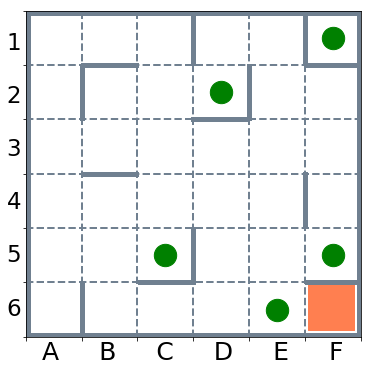

```python
plt.figure(figsize=(6,6))

hlines = [[0.04,0,1],[5.96,0,1],
          [3,0.17,0.33],[5,0.17,0.33],[1,0.34,0.5],
          [4,0.5,0.66],[5,0.84,1],[1,0.84,1]]
for line in hlines:
    plt.axhline(line[0],line[1],line[2],
                lw=5, c='slategray')

vlines = [[0.04,0,1],[5.97,0,1],
          [1,0,0.16],[1,0.67,0.83],[3,0.17,0.33],
          [3,0.84,1],[4,0.67,0.83],[5,0.34,0.5],[5,0.84,1]]
for line in vlines:
    plt.axvline(line[0],line[1],line[2],
                lw=5, c='slategray')

plt.scatter([5.47],[0.55],2200,['coral'], marker='s')
plt.scatter([2.5,3.5,4.5,5.5,5.5],
            [1.5,4.5,0.5,1.5,5.5],
            500,'g', marker='o')

plt.xlim(0,6)
plt.ylim(0,6)

plt.xticks(visible=False)
plt.yticks(visible=False)
plt.xlabel(' A     B     C     D     E     F ', fontsize=25)
plt.ylabel('1  \n\n2  \n\n3  \n\n4  \n\n5  \n\n6  ',
           position = (0.,0.05), fontsize=23, rotation='horizontal')

plt.grid(c='slategray', ls='--', lw=2)
```

```python
answer_dictionary[14] = str(5)
print("\n","Answer:",answer_dictionary[14])
```

```
 Answer: 5
```

[figure not shown]

На карту нанесены 4 города (A, B, C и D).

Известно, что:

- между городами A и C — две дороги,
- между городами A и B — три дороги,
- между городами B и C — четыре дороги,
- между городами C и D — три дороги,
- между городами B и D — три дороги.

По каждой из этих дорог можно ехать в обе стороны.

Сколькими различными способами можно проехать из A в D, посещая каждый город не более одного раза?

The map shows 4 cities (A, B, C and D).

It is known that:

- between the cities A and C - two roads,
- between the cities A and B - three roads,
- between cities B and C - four roads,
- between cities C and D - three roads,
- between cities B and D - three roads.

On each of these roads you can go in both directions.

How many different ways can you travel from A to D, visiting each city no more than one time?

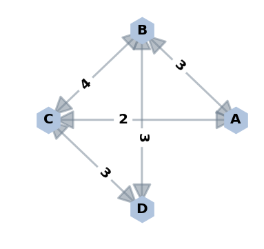

```python
G2 = nx.MultiDiGraph()
plt.figure(figsize=(6,6))

G2.add_weighted_edges_from([('A','B',3), ('A','C',2)])
G2.add_weighted_edges_from([('B','C',4), ('B','D',3)])
G2.add_weighted_edges_from([('C','D',3)])

pos=nx.circular_layout(G2)

nx.draw_networkx_edges(G2, pos, width=3,
                       alpha=0.5, edge_color='slategray',
                       arrowsize=60, arrowstyle='<|-|>')
nx.draw_networkx_nodes(G2, pos, node_size=1500,
                       node_shape='h', node_color='lightsteelblue')
nx.draw_networkx_labels(G2, pos, font_size=20, font_weight='bold')

edge_labels = dict([((u,v,),d['weight']) for u,v,d in G2.edges(data=True)])
nx.draw_networkx_edge_labels(G2,pos,font_size=20,font_weight='bold',
                             label_pos=0.4, edge_labels=edge_labels)
plt.axis('off');
```

| $Пункты \mid Points$ | $Количество \ вариантов \mid Number \ of \ Variants$ |
| --- | --- |
| $A \implies B \implies D$ | $3 * 3 = 9$ |
| $A \implies C \implies D$ | $2 * 3 = 6$ |
| $A \implies B \implies C \implies D$ | $3 * 4 * 3 = 36$ |
| $A \implies C \implies B \implies D$ | $2 * 4 * 3 = 24$ |
| $Итого \mid In \ Total$ | $9 + 6 + 36 + 24 = 75$ |

```python
answer_dictionary[15] = str(3 * 3 + 2 * 3 + 3 * 4 * 3 + 2 * 4 * 3)
print("\n","Answer:",answer_dictionary[15])
```

```
 Answer: 75
```

[figure not shown]

В системе счисления с некоторым основанием десятичное число 51 записывается в виде 102. Укажите это основание.

In the number system with a certain basis, the decimal number 51 is written in the form 102. Indicate this basis.

```python
%%latex
$1 * a^2 + 0 * a^1 + 2 * a^0 = 51 \\
a^2 = 49, \ a \in \mathbb{N} \\
a = 7$
```

$1 * a^2 + 0 * a^1 + 2 * a^0 = 51 \\ a^2 = 49, \ a \in \mathbb{N} \\ a = 7$

```python
answer_dictionary[16] = str(7)
print("\n","Answer:",answer_dictionary[16])
```

```
 Answer: 7
```

[figure not shown]

В таблице приведены запросы к поисковому серверу.

Расположите номера запросов в порядке возрастания количества страниц, которые найдет поисковый сервер по каждому запросу.

В ответе перечислите цифры без пробелов и знаков препинания.

Для обозначения логической операции $«ИЛИ»$ в запросе используется символ $ \mid $, а для логической операции $«И»$ — $\&$.

The table lists the requests to the search server.

Arrange the request numbers in ascending order of the number of pages that the search server will find for each request.

In the answer, list the numbers without spaces and punctuation marks.

To indicate the logical operation $"OR"$, the query uses the symbol $ \mid $, and for the logical operation $"AND"$ - $\&$.

| № | Запрос |
| --- | --- |
| $1$ | *кролики \| лисицы* |
| $2$ | *( зайцы & кролики ) \| ( лисицы & волки )* |
| $3$ | *зайцы & кролики & лисицы & волки* |
| $4$ | *зайцы & кролики* |

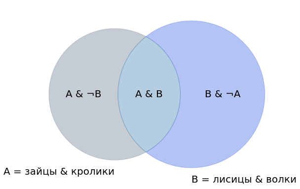

```python
from matplotlib_venn import venn2

plt.figure(figsize=(9,9))
v=venn2(subsets=[5,7,3],
        set_labels=('A = зайцы & кролики', 'B = лисицы & волки'))

v.get_label_by_id('10').set_text('A & ¬B')
v.get_label_by_id('01').set_text('B & ¬A')
v.get_label_by_id('11').set_text('A & B')

v.get_patch_by_id('10').set_color('slategray')
v.get_patch_by_id('01').set_color('royalblue')
v.get_patch_by_id('11').set_color('steelblue')
for text in v.set_labels:
    text.set_fontsize(20)

for text in v.subset_labels:
    text.set_fontsize(20)
plt.show()
```

```python
answer_dictionary[17] = str(3421)
print("\n","Answer:",answer_dictionary[17])
```

```
 Answer: 3421
```

[figure not shown]

Какие из приведённых имён удовлетворяют логическому условию

$(последняя \ буква \ гласная \to вторая \ буква \ согласная) \land первая \ буква \ согласная \ (*)$

1) ВЛАДА

2) АЛИСА

3) МАРИЯ

4) РУСТАМ

5) АРТУР

В ответе перечислите номера имён в порядке возрастания без пробелов и знаков препинания.

Which of the listed names satisfy the logical condition

$(the \ last \ letter \ is \ a \ vowel \to the \ second \ letter \ is \ a \ consonant) \land the \ first \ letter \ is \ a \ consonant \ (*)$

1) ВЛАДА

2) АЛИСА

3) МАРИЯ

4) РУСТАМ

5) АРТУР

In the answer, list the names in ascending order without spaces and punctuation marks.

Обозначим $v$ - гласные буквы, $c$ - согласные.

Let's denote $v$ - vowel letters, $c$ - consonants.

| Имя | Гласные и согласные буквы | Последняя буква гласная | Вторая буква согласная | Первая буква согласная | $(*)$ |
| --- | --- | --- | --- | --- | --- |
| Name | Vowel and Consonant Letters | The Last Letter Is a Vowel | The Second Letter Is a Consonant | The First Letter Is a Consonant | $(*)$ |
| $ВЛАДА$ | `ccvcv` | 1 | 1 | 1 | $(1 \to 1) \land 1 = 1$ |
| $АЛИСА$ | `vcvcv` | 1 | 1 | 0 | $(1 \to 1) \land 0 = 0$ |
| $МАРИЯ$ | `cvcvv` | 1 | 0 | 1 | $(1 \to 0) \land 1 = 0$ |
| $РУСТАМ$ | `cvccvc` | 0 | 0 | 1 | $(0 \to 0) \land 1 = 1$ |
| $АРТУР$ | `vccvc` | 0 | 1 | 0 | $(0 \to 1) \land 0 = 0$ |

```python
answer_dictionary[18] = '14'
print("\n","Answer:", answer_dictionary[18])
```

```
 Answer: 14
```

[figure not shown]

В программе используется целочисленный массив $A$ с индексами от $0$ до $9$.

Значения элементов массива равны $4; 7; 6; 4; 2; 3; 5; 10; 7; 8$ соответственно, т.е. $A[0] = 4; A[1] = 7$ и т.д.

Определите значение переменной $с$ после выполнения следующего фрагмента программы,

записанной ниже на разных языках программирования.

The program uses an integer array $A$ with indices from $0$ to $9$.

The values of the array elements are $4; 7; 6; 4; 2; 3; 5; 10; 7; 8$ respectively, i.e. $A[0] = 4; A[1] = 7$, etc.

Determine the value of the variable $c$ after the next program fragment,

written down below in different programming languages, is executed.

Python

R

```python
A = [4,7,6,4,2,3,5,10,7,8]
c = 0
for i in range(5):
    if A[i] < A[9-i]:
        c += 1
        k = A[i]
        A[i] = A[9-i]
        A[9-i] = k
```

```r
A <- c(4,7,6,4,2,3,5,10,7,8)
c <- 0

for (i in 0:4) {
    if (A[i+1] < A[10-i]) {
        c <- c + 1
        k <- A[i+1]
        A[i+1] <- A[10-i]
        A[10-i] <- k
    }
}
```

```python
A = [4,7,6,4,2,3,5,10,7,8]
c = 0
for i in range(5):
    if A[i] < A[9-i]:
        c += 1
        k = A[i]
        A[i] = A[9-i]
        A[9-i] = k

answer_dictionary[19] = str(c)
print("\n","Answer:", answer_dictionary[19])
```

```
 Answer: 4
```

[figure not shown]

Ниже на нескольких языках записан алгоритм. Получив на вход число х, этот алгоритм печатает число М.

Укажите наибольшее чётное число х, при вводе которого алгоритм печатает 256.

Below in several languages, an algorithm is written. After receiving the number x on the input, this algorithm prints the number M.

Specify the largest even number x, when typing, the algorithm prints 256.

Python

R

```python
x = int(input())
L, M = 0, 1
y = x % 10

while L < x // 10:
    M *= y
    L += 1

print(M)
```

```r
x <- as.integer(readline())
L <-0; M <- 1
y <- x %% 10

while (L < x %/% 10){
    M <- M * y
    L <- L + 1
}

print(M)
```

```python
x = int(input())
L, M = 0, 1
y = x % 10

while L < x // 10:
    M *= y
    L += 1

print(M)
```

```
82
256
```

```python
# расширенная версия программы
for x in range(70,90):
    L, M, t = 0, 1, x
    y = x % 10
    while L < x // 10:
        M = M * y
        L += 1
    print(t, L, M)
    if M == 256:
        answer_dictionary[20] = str(t)
```

```
70 7 0
71 7 1
72 7 128
73 7 2187
74 7 16384
75 7 78125
76 7 279936
77 7 823543
78 7 2097152
79 7 4782969
80 8 0
81 8 1
82 8 256
83 8 6561
84 8 65536
85 8 390625
86 8 1679616
87 8 5764801
88 8 16777216
89 8 43046721
```

```python
print("\n","Answer:", answer_dictionary[20])
```

```
 Answer: 82
```

[figure not shown]

Определите, какое число будет напечатано в результате выполнения следующего алгоритма

(для Вашего удобства алгоритм представлен на нескольких языках):

Determine which number will be printed as a result of the following algorithm

(for your convenience, the algorithm is presented in several languages):

Python

R

```python
def F(x):
    return int((x * x - 9) * (x * x - 9) - 5)

a, b = -25, 25
M, R = a, F(a)

for t in range(a, b+1):
    if F(t) < R:
        M, R = t, F(t)

print(M + 9)
```

```r
F <- function(x) {
        return((x * x - 9) * (x * x - 9) - 5)
}

a <- -25; b <- 25
M <- a; R <- F(a)

for (t in a:b) {
    if (F(t) < R) {
        M <- t; R <- F(t)
    }
}

print(M + 9)
```

```python
def F(x):
    return int((x * x - 9) * (x * x - 9) - 5)

a, b = -25, 25
M, R = a, F(a)

for t in range(a, b+1):
    if F(t) < R:
        M, R = t, F(t)

print(M + 9)
```

```
6
```

```python
answer_dictionary[21] = str(M + 9)
print("\n","Answer:", answer_dictionary[21])
```

```
 Answer: 6
```

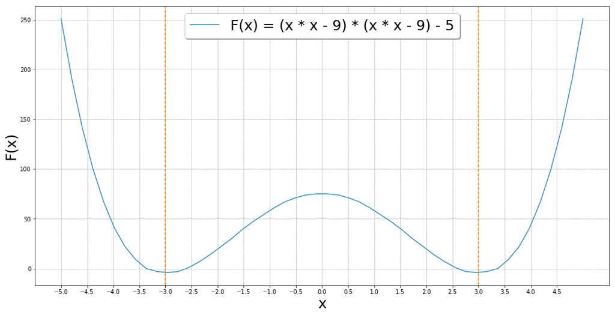

```python
plt.figure(figsize=(18,9))
import numpy
X = numpy.linspace(-5,5)
y = [int((x * x - 9) * (x * x - 9) - 5) for x in X]

plt.plot(X, y, c='#348ABD', label='F(x) = (x * x - 9) * (x * x - 9) - 5')
plt.axvline(3.0, c='darkorange', ls='--')
plt.axvline(-3.0, c='darkorange', ls='--')

plt.xticks(numpy.arange(-5, 5, step=0.5))
plt.xlabel('x', fontsize=25)
plt.ylabel('F(x)', fontsize=25)
plt.grid(c='slategray', ls='--', lw=0.5)
plt.legend(fontsize=25, shadow=True);
```

[figure not shown]

У исполнителя *Кузнечик* две команды:

1. *вычти 3*,
2. *прибавь 5*.

Первая из них уменьшает число на экране на 3, вторая — увеличивает его на 5 (отрицательные числа допускаются).

Программа для *Кузнечика* — это последовательность команд.

Сколько различных чисел можно получить из числа 1 с помощью программы, которая содержит ровно 6 команд?

The performer *Grasshopper* has two commands:

1. *subtract 3*,
2. *add 5*.

The first of them reduces the number on the screen by 3, the second - increases it by 5 (negative numbers are allowed).

The program for *Grasshopper* is a sequence of commands.

How many different numbers can be obtained from the number 1 using a program that contains exactly 6 commands?

[output not shown]

```python
# check the decision method
x = [1]
for i in range(6):
    n = int(len(x) - 2 ** i)
    y = [el - 3 for el in x[n:]]
    z = [el + 5 for el in x[n:]]
    x = x + y + z

print('Length of x:', len(x))
u = numpy.unique(numpy.array(x))
print(u)
```

```
Length of x: 127
[-17 -14 -11  -9  -8  -6  -5  -3  -2  -1   0   1   2   3   5   6   7   8
  10  11  13  15  16  18  21  23  26  31]
```

```python
answer_dictionary[22] = str(len(u))
print("\n","Answer:", answer_dictionary[22])
```

```
 Answer: 28
```

[figure not shown]

Сколько существует различных наборов значений логических переменных $x_1, х_2, ... х_9, x_{10}$,

которые удовлетворяют всем перечисленным ниже условиям?

В ответе не нужно перечислять все различные наборы значений $x_1, х_2, ... х_9, x_{10}$,

при которых выполнена данная система равенств. В качестве ответа вам нужно указать количество таких наборов.

How many different sets of values of logical variables $x_1, х_2, ... х_9, x_{10}$

exist that satisfy all the conditions listed below?

In the answer it is not necessary to list all the different sets of values $x_1, х_2, ... х_9, x_{10}$

for which the given system of equations is satisfied. As an answer, you need to specify only the number of such sets.

- $(x_1 \lor \neg x_2) \land (x_3 \lor \neg x_4) = 1$ **(1)**
- $(x_3 \lor \neg x_4) \land (x_5 \lor \neg x_6) = 1$ **(2)**
- $(x_5 \lor \neg x_6) \land (x_7 \lor \neg x_8) = 1$ **(3)**
- $(x_7 \lor \neg x_8) \land (x_9 \lor \neg x_{10}) = 1$ **(4)**

1) Тождество $(1)$ выполняется только в случае, если пары переменных $(x_1,x_2), (x_3, x_4)$ равны $(0,0),(1,0)$ или $(1,1)$.

Если хотя бы одна из пар $(x_1,x_2), (x_3, x_4)$ равна $(0,1)$ - тождество $(1)$ не выполняется.

Всего получается $9$ наборов переменных $(x_1,x_2,x_3,x_4)$, удовлетворяющих $(1)$: каждой из $3$ пар $(x_1,x_2)$ могут соответствовать $3$ пары $(x_3,x_4)$.

2) Тождество $(2)$ не нарушает ни один из 9 наборов переменных первого пункта, при этом $(x_5,x_6)$ должны быть равны $(0,0),(1,0)$ или $(1,1)$.

Получится $9 * 3 = 27$ вариантов $(x_1,x_2,x_3,x_4,x_5,x_6)$.

3) Рассуждая аналогично, легко видеть закономерность: добавление каждой пары переменных увеличивает количество вариантов в $3$ раза.

$10$ переменных образуют $5$ пар. Значит, общее количество вариантов равно $3 * 3 * 3 * 3 * 3 = 3^5 = 243$.

1) The identity $(1)$ is satisfied only if the pairs of variables $(x_1,x_2), (x_3,x_4)$ are equal to $(0,0), (1,0)$ or $(1,1)$.

If at least one of the pairs $(x_1,x_2), (x_3,x_4)$ is $(0,1)$ - the identity $(1)$ is not satisfied.

In total, $9$ sets of variables $(x_1,x_2,x_3,x_4)$ satisfying $(1)$ are obtained: $3$ pairs $(x_3, x_4)$ can correspond to each of the $3$ pairs $(x_1,x_2)$.

2) The identity $(2)$ does not violate any of $9$ sets of variables from the first step, with $(x_5,x_6)$ being equal to $(0,0), (1,0)$ or $(1,1)$.

So we get $9 * 3 = 27$ variants of $(x_1,x_2,x_3,x_4,x_5,x_6)$.

3) Arguing similarly, it is easy to see the regularity: adding each pair of variables increases the number of variants by $3$ times.

$10$ variables form $5$ pairs. Hence, the total number of variants is $3 * 3 * 3 * 3 * 3 = 3 ^ 5 = 243$

```python
# check the decision method
import itertools

n = 10
binary_combinations = numpy.array(list(itertools.product([0, 1], repeat=n)))
result = []

def logical_function(k,l,m,n):
    return (k or not l) and (m or not n)

for el in binary_combinations:
    e1 = logical_function(el[0],el[1],el[2],el[3])
    e2 = logical_function(el[2],el[3],el[4],el[5])
    e3 = logical_function(el[4],el[5],el[6],el[7])
    e4 = logical_function(el[6],el[7],el[8],el[9])

    result.append(e1 == 1 and e2 == 1 and e3 == 1 and e4 == 1)

answer_dictionary[23] = str(sum(result))
print("\n","Answer:", answer_dictionary[23])
```

```
 Answer: 243
```

## Часть 2 Part 2

[figure not shown]

Требовалось написать программу, которая

- вводит с клавиатуры координаты точки на плоскости (x, у — действительные числа)
- и определяет принадлежность точки заштрихованной области.

Программист торопился и написал программу неправильно.

Последовательно выполните следующее:

1) Приведите пример таких чисел х, у при которых программа работает неправильно.

2) Укажите, как нужно доработать программу, чтобы не было случаев её неправильной работы.

(Это можно сделать несколькими способами, поэтому можно указать любой способ доработки исходной программы).

It was required to write a program that

- enters from the keyboard the coordinates of the point on the plane (x, y are real numbers)
- and determines the belonging of the point to the shaded area.

The programmer was in a hurry and wrote the program incorrectly.

Do the following sequentially:

1) Give an example of such numbers x, y for which the program does not work correctly.

2) Indicate how you need to refine the program so that there are no cases of its improper operation.

(This can be done in several ways, so you can specify any way to refine the source program).

Python

R

```python
import math
x,y = float(input("x = ")), float(input("y = "))
if y <= math.sin(x):
    if y >= 1 - x:
        if y >= 0:
            print('принадлежит')
        else:
            print('не принадлежит')
```

```r
x <- as.numeric(readline("x = ")); y <- as.numeric(readline("y = "))

if (y <= sin(x)) {
    if (y >= 1 - x) {
        if (y >= 0) {
            print('принадлежит')
        } else {
            print('не принадлежит')
        }
    }
}
```

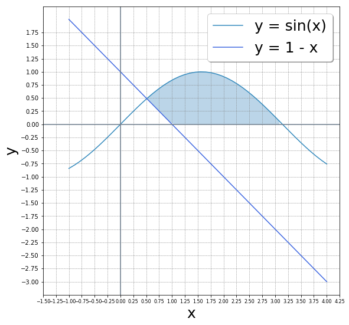

```python
plt.figure(figsize=(9,9))
x = numpy.linspace(-1,4)
sin_x = [math.sin(el) for el in x]
lin_x = [(1 - el) for el in x]
min_y = numpy.maximum(0, lin_x)

plt.plot(x, sin_x, c='#348ABD', label='y = sin(x)')
plt.plot(x, lin_x, c='royalblue', label='y = 1 - x')
plt.fill_between(x, min_y, sin_x, sin_x > min_y, alpha=0.3)

plt.axvline(0, c='slategray', ls='-')
plt.axhline(0, c='slategray', ls='-')

plt.xticks(numpy.arange(-1.5, 4.5, step=0.25), fontsize=8)
plt.yticks(numpy.arange(-3, 2, step=0.25))
plt.xlabel('x', fontsize=25)
plt.ylabel('y', fontsize=25)
plt.grid(c='gray', ls='--', lw=0.5)
plt.legend(fontsize=25, shadow=True);
```

```python
# the wrong variant
import math
x,y = float(input("x = ")), float(input("y = "))
if y <= math.sin(x):
    if y >= 1 - x:
        if y >= 0:
            print('принадлежит')
        else:
            print('не принадлежит')
```

```
x = -6
y = 0
```

```python
# the right variant
x,y = float(input("x = ")), float(input("y = "))
if ((y <= math.sin(x)) and (y >= 1 - x) and (y >= 0)):
    print('принадлежит')
else:
    print('не принадлежит')
```

```
x = -6
y = 0
не принадлежит
```

```python
answer_dictionary[24] = '\n1. (-6,0) \n'+'2. "if y <= math.sin(x): \n      if y >= 1 - x: \n        if y >= 0:" ->\n'+\
                       '"if ((y <= math.sin(x)) and (y >= 1 - x) and (y >= 0)):"'
print("\n","Answer:", answer_dictionary[24])
```

```
 Answer:
1. (-6,0)
2. "if y <= math.sin(x):
      if y >= 1 - x:
        if y >= 0:" ->
"if ((y <= math.sin(x)) and (y >= 1 - x) and (y >= 0)):"
```

[figure not shown]

Дан целочисленный массив из 28 элементов.

Элементы массива могут принимать значения от 0 до 100 — процент выполнения учащимися домашних заданий по информатике.

Для получения положительной оценки за год требовалось набрать не менее 40 баллов.

Опишите на русском языке или на одном из языков программирования алгоритм, который

находит и выводит минимальный балл среди учащихся, получивших за год положительную оценку.

Гарантируется, что в классе хотя бы один учащийся получил за год положительную оценку.

Исходные данные объявлены так, как показано ниже.

Запрещается использовать переменные, не описанные ниже, но разрешается не использовать часть из них.

- Объявляем массив А из 28 элементов.
- Объявляем целочисленные переменные I, J, MIN.
- В цикле от 1 до 28 вводим элементы массива А с 1-го по 28-й.
- ...

В качестве ответа вам необходимо привести фрагмент программы (или описание алгоритма на естественном языке), который должен находиться на месте многоточия.

Вы можете записать решение также на другом языке программирования (укажите название и используемую версию языка программирования, например `Borland Pascal 7.0`) или в виде блок-схемы.

В этом случае вы должны использовать те же самые исходные данные и переменные, какие были предложены в условии (например, в образце, записанном на естественном языке).

An integer array of 28 elements is given.

Elements of the array can take values from 0 to 100 - the percentage of student performing of homeworks in Computer Science.

To get a positive rating for the year it is required to score at least 40 points.

Describe in Russian / English or in one of the programming languages an algorithm that

finds and displays the minimum score among students who received a positive evaluation for the year.

It is guaranteed that in the class at least one student received a positive evaluation for the year.

The original data is declared as shown below.

It is forbidden to use variables not described below, but it is allowed not to use part of them.

- We declare array A of 28 elements.
- Declare the integer variables I, J, MIN.
- In the cycle from 1 to 28, we introduce the elements of array A from the 1st to the 28th.
- ...

As an answer, you need to bring the program fragment (or description of the algorithm in natural language), which should be in place of the ellipsis.

You can also write the solution in another programming language (specify the name and the version of the programming language used, for example `Borland Pascal 7.0`) or as a flowchart.

In this case, you must use the same source data and variables that were proposed in the condition (for example, in a sample written in natural language).

Python

R

```python
N = 28
A = []

#use integer variables I, J, MIN

for I in range(N):
    A.append(int(input()))
    ...
```

```r
N <- 28
A <- vector(length=N)
#use integer variables I, J, MIN

for (I in 1:N){
    A[I] <- as.integer(readline())
...
}
```

```python
print('Процент выполнения учащимися домашних заданий:')
line = 45 * '-='
print(line)
N = 28
A = []
MIN = 100
for I in range(N):
    A.append(int(input()))
    # The fragment instead of the ellipsis
    if (A[I] >= 40) and (A[I] < MIN):
        MIN = A[I]

print(line+'\n'+str(int(MIN)))
```

```
Процент выполнения учащимися домашних заданий:
-=-=-=-=-=-=-=-=-=-=-=-=-=-=-=-=-=-=-=-=-=-=-=-=-=-=-=-=-=-=-=-=-=-=-=-=-=-=-=-=-=-=-=-=-=
78
91
80
63
55
87
67
35
59
72
81
93
68
77
84
49
63
84
90
75
67
86
79
65
72
51
93
64
-=-=-=-=-=-=-=-=-=-=-=-=-=-=-=-=-=-=-=-=-=-=-=-=-=-=-=-=-=-=-=-=-=-=-=-=-=-=-=-=-=-=-=-=-=
49
```

```python
import sys
version = 'python ' + str(sys.version_info[0]) + '.' + str(sys.version_info[1])
```

```python
program_fragment = \
"""
print('Процент выполнения учащимися домашних заданий:')
line = 45 * '-='
print(line)
N = 28
A = []
MIN = 100
for I in range(N):
    A.append(int(input()))
    # The fragment instead of the ellipsis
    if (A[I] >= 40) and (A[I] < MIN):
        MIN = A[I]

print(line+'\n'+str(int(MIN)))
"""
```

```python
answer_dictionary[25] = [version, program_fragment]
print("Answer:", answer_dictionary[25])
```

```
Answer: ['python 3.6', "\nprint('Процент выполнения учащимися домашних заданий:')\nline = 45 * '-='\nprint(line)\nN = 28\nA = []\nMIN = 100\nfor I in range(N):\n    A.append(int(input()))\n    # The fragment instead of the ellipsis \n    if (A[I] >= 40) and (A[I] < MIN): \n        MIN = A[I]\n      …
```

[figure not shown]

У исполнителя *Калькулятор* две команды, которым присвоены номера:

1. *прибавь 3*,
2. *умножь на 3*.

Первая из них увеличивает число на экране на 3, вторая — утраивает его.

Программа для *Калькулятора* — это последовательность команд.

Сколько есть программ, которые число 3 преобразуют в число 93?

Ответ обоснуйте.

The performer *Calculator* has two enumerated commands:

1. *add 3*,
2. *multiply by 3*.

The first of them increases the number on the screen by 3, the second one - triples it.

The program for *Calculator* is a sequence of commands.

How many programs are there, which converts the number 3 to the number 93?

Justify the answer.

При выполнении этой программы можно получить только числа, кратные 3.

With executing this program, it is possible to get only numbers that are multiples of 3.

| Начальные значения → Результат | Количество программ | Примечание |
| --- | --- | --- |
| Initial Values → Result | Number of Programs | Notes |
| 3 → 6 | 1 | $3 + 3$ |
| 3 → 9 | 2 | $3 + 3 + 3 \lor 3 * 3$ |
| 3 → 12 | 2 | $3 + 3 + 3 + 3 \lor 3 * 3 + 3$ |
| 3 → 15 | 2 | $3 + 3 + 3 + 3 + 3 \lor 3 * 3 + 3 + 3$ |
| 3 → 18 | 3 | 3 → 6 + 3 → 9 |
| 3 → 21 | 3 | 3 → 6 + 3 → 9 |
| 3 → 24 | 3 | 3 → 6 + 3 → 9 |
| 3 → 27 | 5 | 3 → 9 + 3 → 18 |
| 3 → 30 | 5 | 3 → 9 + 3 → 18 |
| 3 → 33 | 5 | 3 → 9 + 3 → 18 |
| 3 → 36 | 7 | 3 → 9 + 3 → 27 |
| 3 → 39 | 7 | 3 → 9 + 3 → 27 |
| 3 → 42 | 7 | 3 → 9 + 3 → 27 |
| 3 → 45 | 9 | 3 → 9 + 3 → 36 |
| 3 → 48 | 9 | 3 → 9 + 3 → 36 |
| 3 → 51 | 9 | 3 → 9 + 3 → 36 |
| 3 → 54 | 12 | 3 → 18 + 3 → 45 |
| 3 → 57 | 12 | 3 → 18 + 3 → 45 |
| 3 → 60 | 12 | 3 → 18 + 3 → 45 |
| 3 → 63 | 15 | 3 → 18 + 3 → 54 |
| 3 → 56 | 15 | 3 → 18 + 3 → 54 |
| 3 → 69 | 15 | 3 → 18 + 3 → 54 |
| 3 → 72 | 18 | 3 → 18 + 3 → 63 |
| 3 → 75 | 18 | 3 → 18 + 3 → 63 |
| 3 → 78 | 18 | 3 → 18 + 3 → 63 |
| 3 → 81 | 23 | 3 → 27 + 3 → 72 |
| 3 → 84 | 23 | 3 → 27 + 3 → 72 |
| 3 → 87 | 23 | 3 → 27 + 3 → 72 |
| 3 → 90 | 28 | 3 → 27 + 3 → 81 |
| 3 → 93 | 28 | 3 → 27 + 3 → 81 |

```python
answer_dictionary[26] = str(28)
print("\n","Answer:", answer_dictionary[26])
```

```
 Answer: 28
```

[figure not shown]

После единых выпускных экзаменов по информатике в район пришла информация о том, какой ученик какой школы сколько баллов набрал.

Эта информация в том же виде была разослана в школы.

Завуч школы № 50 решила наградить двух учащихся, которые лучше всех в школе сдали информатику.

Программа должна вывести на экран фамилии и имена этих учеников.

Если наибольший балл набрало больше двух человек — вывести количество таких учеников.

Если наибольший балл набрал один человек, а следующий балл набрало несколько человек — нужно вывести только фамилию и имя лучшего.

Напишите эффективную, в том числе и по используемой памяти, программу (укажите используемую версию языка программирования, например, `Borland Pascal 7.0`), которая должна вывести на экран требуемую информацию.

Известно, что информатику сдавало больше 5-ти учеников школы № 50.

На вход программе сначала подаётся число учеников, сдававших экзамен. В каждой из следующих N строк находится информация об учениках в формате:

`<Фамилия>` `<Имя>` `<Номер школы>` `<Количество баллов>`,

где `<Фамилия>` — строка, состоящая не более, чем из 30 символов без пробелов, `<Имя>` — строка, состоящая не более, чем из 20 символов без пробелов, `<Номер школы>` — целое число в диапазоне от 1 до 99, `<Количество баллов>` — целое число диапазоне от 1 до 100. Эти данные записаны через пробел, причём ровно один между каждой парой (то есть, всего по три пробела в каждой строке).

Пример входной строки:

Иванов Иван 50 87

Пример выходных данных:

Круглов Василий

Тарасова Дарья

Другой вариант выходных данных:

7

Третий вариант выходных данных:

Гусарский Илья

After the uniform final examination in informatics, information was received in the district about which pupil of which school scored how many points.

This information was sent in the same form to schools.

The head teacher of the school No. 50 decided to award two students who passed Computer Science at the best level in the school.

The program should display surnames and names of these students on the screen.

If the greatest score more than two people have had then the program should print the number of these students.

If the maximum value has one person, and the next score is a result of several people - the program should display only the surname and the name of the best student.

Write an effective program, including the memory used (specify the version of the programming language used, for example, `Borland Pascal 7.0`), which should display the required information.

It is known that more than 5 pupils of school No. 50 passed Computer Science.

The entrance to the program is first given the number of students who passed the exam. Each of the following N lines contains information about students in the format:

`<Surname>` `<Name>` `<School number>` `<Number of points>`,

where `<Surname>` is a string consisting of no more than 30 characters without spaces, `<Name>` is a string consisting of not more than 20 characters without spaces, `<School number>` is an integer in the range from 1 to 99, `<The number of points>` is an integer ranging from 1 to 100. These data are written in a space, with exactly one between each pair (that is, only three spaces in each line).

Example of an input line:

Ivanov Ivan 50 87

Example of an output line:

Kruglov Vasily

Tarasova Daria

Another variant of the output line:

7

The third variant of the output line:

Gusarskiy Ilya

Пример персональных данных для тестирования программы.

An example of data points for testing the program.

1. Аверин Алексей 7 78
2. Бодрова Екатерина 38 81
3. Бондарев Максим 50 65
4. Вершинин Денис 7 87
5. Воронова Галина 7 76
6. Газиев Марат 38 83
7. Грачев Иван 38 67
8. Есин Руслан 50 88
9. Колесникова Мария 38 74
10. Лескова Анна 50 83
11. Мельников Роман 38 77
12. Морозова Жанна 50 88
13. Нестерова Роза 38 81
14. Нигматулин Ринат 7 72
15. Носиков Илья 50 88
16. Ольховский Дмитрий 7 79
17. Петренко Дарья 7 82
18. Робертсон Артур 38 73
19. Стариков Кирилл 50 70
20. Терехов Леонид 7 84

```python
# без использования импортируемых модулей
N = int(input('Число учеников, сдававших экзамен: '))
S = int(input('Номер школы: '))
scores = 101 * [0]
students = 101 * ['']
MAX = 0

print('Персональные данные в формате: ')
print('<Фамилия><пробел><Имя><пробел><Номер школы><пробел><Количество баллов>')
print(18*'=-=')

for i in range(N):
    print(("{} ученик").format(i+1))
    string = input().split()

    if int(string[2]) == S:
        score = int(string[3])
        student = string[0] + ' ' + string[1]
        scores[score] += 1
        students[score] += '\n' + student

        if MAX < score:
            MAX = score

j = 1
while scores[MAX-j] == 0:
    j += 1

if scores[MAX] > 1 or (scores[MAX] == 1 and scores[MAX-j] > 1):
    print (students[MAX])
elif scores[MAX] == 1 and scores[MAX-j] == 1:
    print (students[MAX])
    print (students[MAX-j])
```

```
Число учеников, сдававших экзамен: 20
Номер школы: 50
Персональные данные в формате:
<Фамилия><пробел><Имя><пробел><Номер школы><пробел><Количество баллов>
=-==-==-==-==-==-==-==-==-==-==-==-==-==-==-==-==-==-=
1 ученик
Грачев Иван 38 67
2 ученик
Бодрова Екатерина 38 81
3 ученик
Бондарев Максим 50 65
4 ученик
Вершинин Денис 7 87
5 ученик
Воронова Галина 7 76
6 ученик
Газиев Марат 38 83
7 ученик
Грачев Иван 38 67
8 ученик
Есин Руслан 50 88
9 ученик
Колесникова Мария 38 74
10 ученик
Лескова Анна 50 83
11 ученик
Мельников Роман 38 77
12 ученик
Морозова Жанна 50 88
13 ученик
Нестерова Роза 38 81
14 ученик
Нигматулин Ринат 7 72
15 ученик
Носиков Илья 50 88
16 ученик
Ольховский Дмитрий 7 79
17 ученик
Петренко Дарья 7 82
18 ученик
Робертсон Артур 38 73
19 ученик
Стариков Кирилл 50 70
20 ученик
Терехов Леонид 7 84

Есин Руслан
Морозова Жанна
Носиков Илья
```

```python
print(scores,'\n',students,'\n',MAX,'\n',j)
```

[output not shown]

```python
program = \
"""
N = int(input('Число учеников, сдававших экзамен: '))
S = int(input('Номер школы: '))
scores = 101 * [0]
students = 101 * ['']
MAX = 0

print('Персональные данные в формате: ')
print('<Фамилия><пробел><Имя><пробел><Номер школы><пробел><Количество баллов>')
print(18*'=-=')

for i in range(N):
    print(("{} ученик").format(i+1))
    string = input().split()

    if int(string[2]) == S:
        score = int(string[3])
        student = string[0] + ' ' + string[1]
        scores[score] += 1
        students[score] += '\n' + student

        if MAX < score:
            MAX = score

j = 1
while scores[MAX-j] == 0:
    j += 1

if scores[MAX] > 1 or (scores[MAX] == 1 and scores[MAX-j] > 1):
    print (students[MAX])
elif scores[MAX] == 1 and scores[MAX-j] == 1:
    print (students[MAX])
    print (students[MAX-j])
"""
```

```python
answer_dictionary[27] = [version, program]
print("\n","Answer:", answer_dictionary[27])
```

```
 Answer: ['python 3.6', '\nN = int(input(\'Число учеников, сдававших экзамен: \'))\nS = int(input(\'Номер школы: \'))\nscores = 101 * [0]\nstudents = 101 * [\'\']\nMAX = 0\n\nprint(\'Персональные данные в формате: \')\nprint(\'<Фамилия><пробел><Имя><пробел><Номер школы><пробел><Количество баллов>\')…
```

```python
# с использованием импортируемых модулей
line = 18*"=-= "
print(line)
N = int(input("Число учеников, сдававших экзамен: "))
print(line)
print("Персональные данные в формате: ")
print("<Фамилия><пробел><Имя><пробел><Номер школы><пробел><Количество баллов>")
print(line)

df = pandas.DataFrame(index=range(1,N+1,1),
                      columns=['Фамилия', 'Имя', 'Номер школы', 'Количество баллов'])
df = df.fillna(0)

for i in range(1,N+1,1):
    print(("{} ученик").format(i))
    df.loc[i] = input("").split()
```

```
=-= =-= =-= =-= =-= =-= =-= =-= =-= =-= =-= =-= =-= =-= =-= =-= =-= =-=
Число учеников, сдававших экзамен: 20
=-= =-= =-= =-= =-= =-= =-= =-= =-= =-= =-= =-= =-= =-= =-= =-= =-= =-=
Персональные данные в формате:
<Фамилия><пробел><Имя><пробел><Номер школы><пробел><Количество баллов>
=-= =-= =-= =-= =-= =-= =-= =-= =-= =-= =-= =-= =-= =-= =-= =-= =-= =-=
1 ученик
Аверин Алексей 7 78
2 ученик
Бодрова Екатерина 38 81
3 ученик
Бондарев Максим 50 65
4 ученик
Вершинин Денис 7 87
5 ученик
Воронова Галина 7 76
6 ученик
Газиев Марат 38 83
7 ученик
Грачев Иван 38 67
8 ученик
Есин Руслан 50 88
9 ученик
Колесникова Мария 38 74
10 ученик
Лескова Анна 50 83
11 ученик
Мельников Роман 38 77
12 ученик
Морозова Жанна 50 88
13 ученик
Нестерова Роза 38 81
14 ученик
Нигматулин Ринат 7 72
15 ученик
Носиков Илья 50 88
16 ученик
Ольховский Дмитрий 7 79
17 ученик
Петренко Дарья 7 82
18 ученик
Робертсон Артур 38 73
19 ученик
Стариков Кирилл 50 70
20 ученик
Терехов Леонид 7 84
```

```python
df['Количество баллов'] = df['Количество баллов'].astype('int32')
df['Номер школы'] = df['Номер школы'].astype('int32')

df50 = df[df['Номер школы'] == 50]
scores50 = df50['Количество баллов'].value_counts().sort_index(ascending=False)
df50 = df50[['Фамилия', 'Имя']].as_matrix()

if (scores50.iloc[0] == 1) and (scores50.iloc[1] > 1):
    print(df50[0][0] + ' ' + df50[0][1])

elif (scores50.iloc[0] == 2) or (scores50.iloc[0] + scores50.iloc[1] == 2):
    print(df50[0][0] + ' ' + df50[0][1])
    print(df50[1][0] + ' ' + df50[1][1])

elif scores50.iloc[0] > 2:
    print(scores50.iloc[0])
```

```
3
```

```python
scores50
```

```
88    3
83    1
70    1
65    1
Name: Количество баллов, dtype: int64
```

```python
df38 = df[df['Номер школы'] == 38]
scores38 = df38['Количество баллов'].value_counts().sort_index(ascending=False)
df38 = df38[['Фамилия', 'Имя']].as_matrix()

if (scores38.iloc[0] == 1) and (scores38.iloc[1] > 1):
    print(df38[0][0]+' '+df38[0][1])

elif (scores38.iloc[0] == 2) or (scores38.iloc[0] + scores38.iloc[1] == 2):
    print(df38[0][0] + ' ' + df38[0][1])
    print(df38[1][0] + ' ' + df38[1][1])

elif scores38.iloc[0] > 2:
    print(scores38.iloc[0])
```

```
Бодрова Екатерина
```

```python
scores38
```

```
83    1
81    2
77    1
74    1
73    1
67    1
Name: Количество баллов, dtype: int64
```

```python
df7 = df[df['Номер школы'] == 7]
scores7 = df7['Количество баллов'].value_counts().sort_index(ascending=False)
df7 = df7[['Фамилия', 'Имя']].as_matrix()

if (scores7.iloc[0] == 1) and (scores7.iloc[1] > 1):
    print(df7[0][0]+' '+df7[0][1])

elif (scores7.iloc[0] == 2) or (scores7.iloc[0] + scores7.iloc[1] == 2):
    print(df7[0][0] + ' ' + df7[0][1])
    print(df7[1][0] + ' ' + df7[1][1])

elif scores7.iloc[0] > 2:
    print(scores7.iloc[0])
```

```
Аверин Алексей
Вершинин Денис
```

```python
scores7
```

```
87    1
84    1
82    1
79    1
78    1
76    1
72    1
Name: Количество баллов, dtype: int64
```

## Ответы Answers

```python
answer_dictionary
```

```
{1: '4',
 2: '135',
 3: '4',
 4: '2',
 5: 'DF4C',
 6: 'C',
 7: 6,
 8: '20',
 9: '32',
 10: '24',
 11: '720',
 12: 'CDBA',
 13: '420',
 14: '5',
 15: '75',
 16: '7',
 17: '3421',
 18: '14',
 19: '4',
 20: '82',
 21: '6',
 22: '28',
 23: '243',
 24: '\n1. (-6,0) \n2. "if y <= math.sin(x): \n      if y >= 1 - x: \n        if y >= 0:" ->\n"if ((y <= math.sin(x)) and (y >= 1 - x) and (y >= 0)):"',
 25: ['python 3.6',
  "\nprint('Процент выполнения учащимися домашних заданий:')\nline = 45 * '-='\nprint(line)\nN = 28\nA = []\nMIN = 100\nfor I in range(N):\n    A.append(int(input()))\n    # The fragment instead of the ellipsis \n    if (A[I] >= 40) and (A[I] < MIN): \n        MIN = A[I]\n        \nprint(line+'\n'+s…
 26: '28',
 27: ['python 3.6',
  '\nN = int(input(\'Число учеников, сдававших экзамен: \'))\nS = int(input(\'Номер школы: \'))\nscores = 101 * [0]\nstudents = 101 * [\'\']\nMAX = 0\n\nprint(\'Персональные данные в формате: \')\nprint(\'<Фамилия><пробел><Имя><пробел><Номер школы><пробел><Количество баллов>\')\nprint(18*\'=-=\')\n\…
```